# Bellabeat Analysis

# Business Task

The goal of this data analysis is to explore and identify how consumers use non-Bellabeat smart devices, how these usage trends may apply to Bellbeat users, and how these insights can help improve marketing strategies for the company.

#### Main questions:

> 1. How do consumers use non-Bellabeat smart devices?
> 2. Are there certain days/times when smart device users are more active (measured by the number of steps taken per day and per hour)?
> 3. How did device usage change over time (measured by the number of unique participant entries by a per day)?
> 4. How might FitBit trends apply to Bellbeat users?
> 5. How can these trends be used to improve Bellabeat marketing strategies?

# Data Source and Limitations

## Data Source

[FitBit Fitness Tracker Data](https://www.kaggle.com/arashnic/fitbit) (CC0: public domain, available from Kaggle user Mobius) including the subsets:

1. dailyActivity_merged
2. hourlyCalories_merged
3. hourlySteps_merged
4. sleepDay_merged
5. heartrate_seconds_merged
6. weightLogInfo_merged

## Data Limitations

The following criteria were used to evaluate the data set. The criteria are color-coded to represent whether or not each is satisfied–green indicates that the criterion is satisfied, yellow indicates it is partially satisfied, and red indicates it is not satisfied.

[output not shown]

# Data Cleaning and Manipulation

RStudio was used to clean and manipulate the FitBit Fitness Tracker data set due to the size and complexity of the data set. The complete code can be found [here](https://github.com/Callyforniaa/Bellabeat/blob/main/bellabeat_analysis.R).

The data subsets listed above were merged into 4 combined data frames. Some variables were manipulated to improve consistency of the data frames. A summary of the changes made can be found below.

[output not shown]

# Analysis Summary

This table gives a quick overview of the analysis results for each data frame. More details on the significant findings from the analysis (including visualizations) can be found in the following sections.

[output not shown]

## Daily Activity

#### Average Steps by Day of the Week

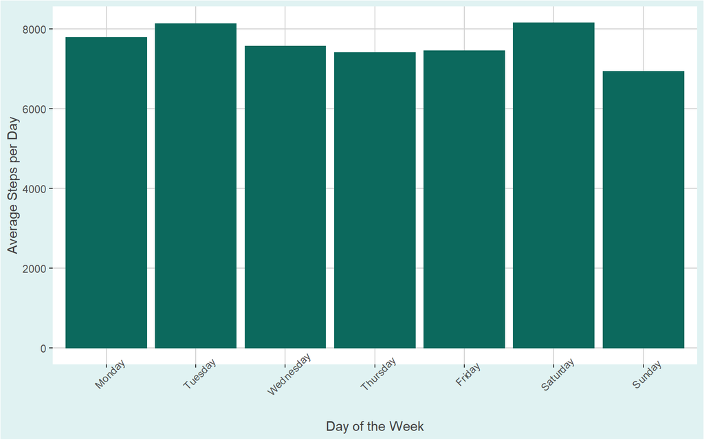

**Finding**: Saturday is the most active day (average of 8,153 steps), followed closely by Tuesday (average of 8,125 steps). Sunday is the least active day (average of 6,933 steps). On average, participants took about 6.7% more steps on Saturday than the rest of the week. For Sunday, participants took about 9.2% fewer steps.

#### Number of Entries per Day

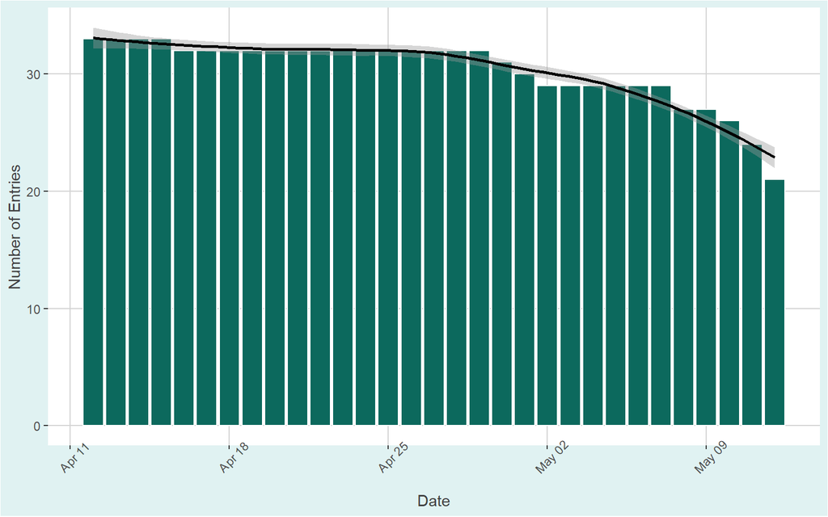

**Finding**: The number of daily entries declined as the study went on, suggesting some participants were using their devices less over time. The decline was most noticeable during the 5th week of the data collection period.

## Hourly Activity

#### Average Steps per Hour

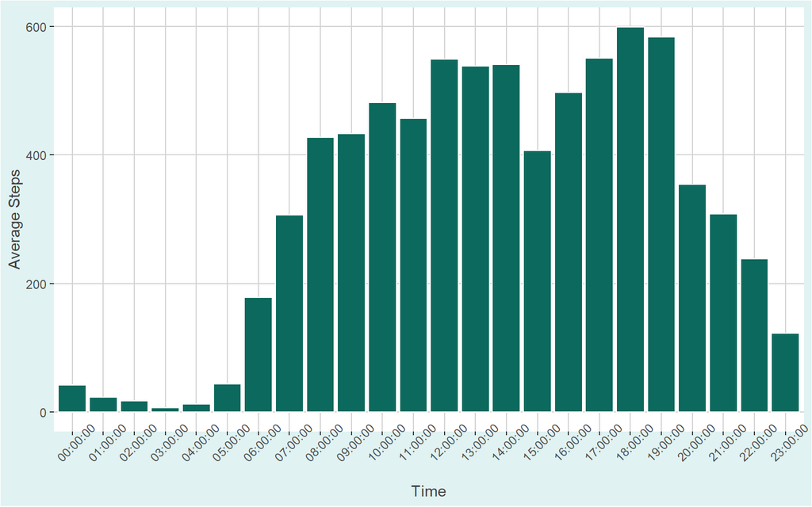

## Heart Rate and Weight Log

The heart rate and weight log data frames were analyzed, but no meaningful trends were identified. See [the full code](https://github.com/Callyforniaa/Bellabeat/blob/main/bellabeat_analysis.R) for more detail.

# Key Findings

#### How Participants Used FitBit

> - **Some users may have more than one device.**  
>   There were 30 participants in the study but 33 participant IDs, suggesting some participants used more than one device.
> - **Not all participants used every feature.**  
>   Overall, the weight log was the least used feature, with only 8 participants (24%) reporting their data. Other features with limited data were daily sleep tracking (24 participants, 73%) and heart rate measurements (14 participants, 42%).
> - **Participants may use the device less over time.**  
>   The number of daily activity entries slightly declines as time goes on, suggesting participants may have been using their devices less frequently. The decline was most noticeable during week 5.

# Recommendations

#### Based on what we learned, we should:

> 1. Market the different Bellabeat devices as a system. This encourages users to purchase multiple products that work together to provide a complete picture of their health/fitness.
> 2. Focus our marketing on the more popular features that Bellbeat also offers, such as step and calorie counts.
> 3. Use qualitative methods to explore why FitBit users don’t use certain features such as the weight log, heart rate, and sleep tracker (i.e. are they inaccurate, do they require manual logs, are the devices uncomfortable to sleep in? Do customers typically use the time they sleep to charge their device? etc.)
> 4. Use these qualitative findings to improve Bellabeat features and solve the issues that FitBit users identified for their own devices. This can give us a competitive edge.
> 5. Develop strategies to encourage continued use of Bellabeat devices. For example, focus on developing updates that offer new features for our customers, or simply providing prompts to continue use directly from the device.
> 6. Consider expanding our marketing to target other populations (i.e. overweight) that are not as prominent in the FitBit community.
> 7. Consider peak activity days and hours to ensure the software is providing prompts that are appropriately timed and useful for our users.